# Su et al., (2024): Figure 4D-F

# Load and tidy data

Data was exported from VideoFreeze as CSV files. The header rows of the raw CSV files contain information regarding how the data was exported (ie how data was segmented into bins as well as what motion index threshold was used as a cut-off for assessing freezing).

```r
# df ---------------------------------------------------

list.files(pattern=".csv$", recursive = TRUE)
```

```
##  [1] "PREE_INTERPOLATE/PREE #16/2024-03-30_FC1_R1_CR.csv"
##  [2] "PREE_INTERPOLATE/PREE #16/2024-03-30_FC1_R1_PR.csv"
##  [3] "PREE_INTERPOLATE/PREE #16/2024-03-30_FC1_R2_CR.csv"
##  [4] "PREE_INTERPOLATE/PREE #16/2024-03-30_FC1_R2_PR.csv"
##  [5] "PREE_INTERPOLATE/PREE #16/2024-03-31_IPE_R1_NA.csv"
##  [6] "PREE_INTERPOLATE/PREE #16/2024-03-31_IPE_R2_NA.csv"
##  [7] "PREE_INTERPOLATE/PREE #16/2024-04-01_FC2_R1_CR.csv"
##  [8] "PREE_INTERPOLATE/PREE #16/2024-04-01_FC2_R1_PR.csv"
##  [9] "PREE_INTERPOLATE/PREE #16/2024-04-01_FC2_R2_CR.csv"
## [10] "PREE_INTERPOLATE/PREE #16/2024-04-01_FC2_R2_PR.csv"
## [11] "PREE_INTERPOLATE/PREE #16/2024-04-02_E1_R1_NA.csv"
## [12] "PREE_INTERPOLATE/PREE #16/2024-04-02_E1_R2_NA.csv"
```

```r
list.filenames <- list.files(".", pattern = ".csv$",
                             full.names=TRUE, recursive = TRUE)
# delete the metadata from the list.filenames
list.data <- list()

for (i in 1:length(list.filenames)) {
  list.data[[i]] <- read.csv(list.filenames[[i]], skip=
                               ifelse(str_detect(list.filenames[[i]], "FC\\w*CR.csv$"), 15,
                                      ifelse(str_detect(list.filenames[[i]], "FC\\w*PR.csv$"), 18,
                                             ifelse(str_detect(list.filenames[[i]], "IPE"), 32,
                                                    ifelse(str_detect(list.filenames[[i]], "E1"), 24,
                                                           ifelse(str_detect(list.filenames[[i]], "SR"), 16,
                                                                  24)))))
  )
  list.data[[i]]$ExpDetails <- str_sub(list.filenames[[i]], 29, -5)

}

list.data <- list.data %>%
  reduce(full_join) %>% #collapse separate items in list into one
  separate(col=ExpDetails, into = c("Exp_Date", "Exp_Type", "Exp_Room", "Exp_Sched"), sep = "_") %>%
  separate(col=Group, into = c("R_Schedule", "Interpolated"), sep = "_") %>%
  mutate(id = Animal) %>%
  separate(col = Animal, into = c("Strain", "Sex", "Cage", "Chamber"), sep = "-")
```

[output not shown]

```r
# Conver list into a dataframe
df<-as.data.frame(list.data)

rm(list=setdiff(ls(), "df"))
# df<- df %>%
#   drop_na(Trial, Strain, Experiment)

#write_csv(df, "220803_PREE_df.csv")
```

# Fig 4. Testing effect of interpolated extinction (A-C) and less fear training (D-F) on FE

### E - Dataframe

```r
FC_id_1 <- df %>%
  filter(str_detect(Component.Name, "pre-tone|post-tone", negate = TRUE),
         str_detect(Exp_Type, "FC")) %>%
  group_by(id, R_Schedule, Interpolated) %>%
  summarize(mean_freezing=mean(Pct.Component.Time.Freezing), n=n(),
            se=sd(Pct.Component.Time.Freezing/sqrt(n()))) %>%
  na.omit()
#write_csv(FC_id, "220803_PREE_FC_id.csv")

FC_ave_1 <- FC_id_1 %>%
  group_by(R_Schedule, Interpolated) %>%
  summarize(group_mean_freezing=mean(mean_freezing), n=n(),
            se=sd(mean_freezing/sqrt(n())))
#write_csv(FC_ave, "220803_PREE_FC_ave.csv")
```

### E - Graph

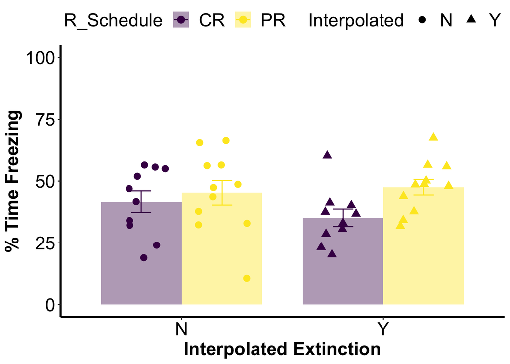

```r
ggplot(FC_ave_1,
       aes(x=Interpolated,
           y=group_mean_freezing,
           group=interaction(R_Schedule, Interpolated),
           color=R_Schedule,
           fill=R_Schedule,
           shape=Interpolated)) +
  scale_fill_viridis(discrete = TRUE) +
  scale_colour_viridis(discrete = TRUE) +
  geom_bar(
    stat = "identity",
    position = "dodge",
    width=0.8,
    alpha=0.4,
    color=NA) +
  geom_errorbar(
    aes(
      ymin = group_mean_freezing-se,
      ymax = group_mean_freezing+se,
      width = .2),
    position=position_dodge(width=0.8)
  ) +
  geom_point(
    data=FC_id_1,
    aes(x=Interpolated, y=mean_freezing),
    position = position_jitterdodge(jitter.height=0, jitter.width=0.25,
                                    dodge.width = 0.8),
    size=3
  ) +
  ylim(0,100) +
  theme_bw() +
  theme(legend.text=element_text(size=18),
        legend.title = element_text(size=18),
        legend.position = "top",
        panel.border= element_blank(),
        plot.background = element_blank(),
        plot.title = element_text(size = 18,face="bold.italic", hjust=0.5),
        panel.grid.major = element_blank(),
        panel.grid.minor = element_blank(),
        axis.text.x = element_text(size = 18, color="black"),
        axis.text.y = element_text(size = 18, color="black"),
        axis.title.x = element_text(size = 18, face= "bold"),
        axis.title.y = element_text(size = 18, face="bold"),
        axis.line.x = element_line(color="black", size = 1),
        axis.line.y = element_line(color="black", size = 1),
        strip.text = element_text(size = 18)) +
  labs(
    x = "Interpolated Extinction",
    y = "% Time Freezing")
```

### E - Stats

Sex was originally in the statistical model: mean_freezing ~ Contingency (2) X CS_time (2) X Sex (2). However, considering broad lack of sex-specific effects, it was dropped from models.

```r
m4e <- FC_id_1 %>%
  aov_ez(id = "id",
         dv = "mean_freezing",
         between = c("R_Schedule", "Interpolated"),
         data = .)
```

```
## Converting to factor: R_Schedule, Interpolated
```

```
## Contrasts set to contr.sum for the following variables: R_Schedule, Interpolated
```

```r
#ANOVA table
nice_m4e <-nice(m4e)
kable(nice_m4e, caption = '<b>Figure 4E: Main FX</b>') %>%
  kable_styling(bootstrap_options = "striped", full_width = F, position = "left")
```

**Figure 4E: Main FX**

| Effect | df | MSE | F | ges | p.value |
| --- | --- | --- | --- | --- | --- |
| R_Schedule | 1, 38 | 174.21 | 3.82 + | .091 | .058 |
| Interpolated | 1, 38 | 174.21 | 0.27 | .007 | .605 |
| R_Schedule:Interpolated | 1, 38 | 174.21 | 1.16 | .030 | .288 |